# Chapter 2: Seminar - ARMA Models Exercises

### Quiz 14: Residual Diagnostics

**Question:** After fitting an ARMA model, you examine the residuals and find:

- ACF shows significant spikes at lags 12 and 24
- No significant autocorrelation at other lags
- Ljung-Box test p-value = 0.03 at lag 20

What is the most likely issue?

- A) The model is overfitting the data
- B) The series has unmodeled seasonal patterns
- C) The residuals are perfectly white noise
- D) The model has too few AR terms

```python
# Enter your answer: 'A', 'B', 'C', or 'D'
quiz14_answer = ''  # <-- Enter your answer here

# Check answer
if quiz14_answer.upper() == 'B':
    print("CORRECT!")
    print()
    print("Diagnostic Interpretation:")
    print()
    print("Key clues:")
    print("1. Significant ACF at lags 12 and 24 (multiples of 12)")
    print("2. This suggests MONTHLY seasonality (period = 12)")
    print("3. Ljung-Box p-value < 0.05 confirms residual autocorrelation")
    print()
    print("Diagnosis: SEASONAL PATTERNS not captured by the ARMA model")
    print()
    print("Solutions:")
    print("- Use SARIMA (Seasonal ARIMA) instead of ARMA")
    print("- Add seasonal differencing: (1 - L^12)")
    print("- Include seasonal AR/MA terms: SAR(1), SMA(1)")
    print()
    print("Example SARIMA notation: ARIMA(p,d,q)(P,D,Q)_12")
    print("where (P,D,Q) are seasonal AR, differencing, and MA orders")
elif quiz14_answer:
    print("Incorrect. Try again!")
    print("Hint: What do spikes at lags 12 and 24 suggest about the data structure?")
```

### Quiz 15: Box-Jenkins Methodology

**Question:** The Box-Jenkins methodology consists of three main stages. What is the correct ORDER of these stages?

- A) Estimation -> Identification -> Diagnostic Checking
- B) Identification -> Diagnostic Checking -> Estimation
- C) Identification -> Estimation -> Diagnostic Checking
- D) Diagnostic Checking -> Identification -> Estimation

```python
# Enter your answer: 'A', 'B', 'C', or 'D'
quiz15_answer = ''  # <-- Enter your answer here

# Check answer
if quiz15_answer.upper() == 'C':
    print("CORRECT!")
    print()
    print("Box-Jenkins Methodology (3 Stages):")
    print()
    print("1. IDENTIFICATION")
    print("   - Check stationarity (ADF test, plot)")
    print("   - Transform if needed (differencing, log)")
    print("   - Examine ACF/PACF to determine p and q")
    print("   - Select candidate models")
    print()
    print("2. ESTIMATION")
    print("   - Estimate parameters (MLE or CSS)")
    print("   - Compare models using AIC/BIC")
    print("   - Check parameter significance")
    print()
    print("3. DIAGNOSTIC CHECKING")
    print("   - Analyze residuals (ACF, Ljung-Box)")
    print("   - Check normality (Q-Q plot, Jarque-Bera)")
    print("   - If diagnostics fail, return to Stage 1")
    print()
    print("This is an ITERATIVE process until a satisfactory model is found!")
elif quiz15_answer:
    print("Incorrect. Try again!")
    print("Hint: You need to identify the model before you can estimate it.")
```

### Quiz 16: Characteristic Equation Roots

**Question:** For the AR(2) process $X_t = 1.2X_{t-1} - 0.35X_{t-2} + \varepsilon_t$, the characteristic equation $1 - 1.2z + 0.35z^2 = 0$ has roots $z_1 = 2$ and $z_2 = \frac{10}{7} \approx 1.43$. Is this process stationary?

- A) Yes, because both roots are positive
- B) Yes, because both roots are outside the unit circle (|z| > 1)
- C) No, because the roots are not equal
- D) No, because the sum of the coefficients exceeds 1

```python
# Enter your answer: 'A', 'B', 'C', or 'D'
quiz16_answer = ''  # <-- Enter your answer here

# Check answer
if quiz16_answer.upper() == 'B':
    print("CORRECT!")
    print()
    print("Stationarity Check via Characteristic Roots:")
    print()
    print("AR(p) is stationary iff ALL roots of phi(z) = 0 lie OUTSIDE the unit circle")
    print()
    print("Given roots: z1 = 2, z2 = 10/7 ≈ 1.43")
    print()
    print("Check:")
    print(f"  |z1| = |2| = 2 > 1  ✓")
    print(f"  |z2| = |10/7| = 1.43 > 1  ✓")
    print()
    print("Both roots are outside the unit circle -> STATIONARY")
    print()
    print("Verification using coefficient conditions for AR(2):")
    phi1, phi2 = 1.2, -0.35
    print(f"  phi1 + phi2 = {phi1 + phi2} < 1  ✓")
    print(f"  phi2 - phi1 = {phi2 - phi1} < 1  ✓")
    print(f"  |phi2| = {abs(phi2)} < 1  ✓")
    print()
    print("All stationarity conditions satisfied!")
elif quiz16_answer:
    print("Incorrect. Try again!")
    print("Hint: What condition must characteristic roots satisfy for stationarity?")
```

### Quiz 17: AR Memory and Persistence

**Question:** Consider two AR(1) processes:

- Process A: $X_t = 0.95 X_{t-1} + \varepsilon_t$
- Process B: $X_t = 0.5 X_{t-1} + \varepsilon_t$

Both experience a unit shock at time t=0. After 10 periods, what fraction of the original shock remains in each process?

- A) Process A: 60%, Process B: 0.1%
- B) Process A: 95%, Process B: 50%
- C) Process A: 9.5%, Process B: 5%
- D) Process A: 0%, Process B: 0% (shocks have no lasting effect)

```python
# Enter your answer: 'A', 'B', 'C', or 'D'
quiz17_answer = ''  # <-- Enter your answer here

# Check answer
if quiz17_answer.upper() == 'A':
    print("CORRECT!")
    print()
    print("Shock Persistence in AR(1):")
    print()
    print("After h periods, fraction remaining = phi^h")
    print()
    print("Process A (phi = 0.95):")
    phi_A = 0.95
    remaining_A = phi_A ** 10
    print(f"  phi^10 = 0.95^10 = {remaining_A:.4f} = {remaining_A*100:.1f}%")
    print()
    print("Process B (phi = 0.5):")
    phi_B = 0.5
    remaining_B = phi_B ** 10
    print(f"  phi^10 = 0.5^10 = {remaining_B:.4f} = {remaining_B*100:.2f}%")
    print()
    print("Interpretation:")
    print("- Process A: HIGH persistence (slow mean reversion)")
    print("  Shocks take a long time to dissipate")
    print("- Process B: LOW persistence (fast mean reversion)")
    print("  Shocks dissipate quickly")
    print()
    print("Half-life (time for shock to decay by 50%):")
    import numpy as np
    half_life_A = np.log(0.5) / np.log(phi_A)
    half_life_B = np.log(0.5) / np.log(phi_B)
    print(f"  Process A: {half_life_A:.1f} periods")
    print(f"  Process B: {half_life_B:.1f} periods")
elif quiz17_answer:
    print("Incorrect. Try again!")
    print("Hint: In AR(1), the effect of a shock after h periods is phi^h.")
```

### Quiz 18: MA(q) ACF Cutoff

**Question:** For an MA(3) process $X_t = \varepsilon_t + \theta_1\varepsilon_{t-1} + \theta_2\varepsilon_{t-2} + \theta_3\varepsilon_{t-3}$, what can we say about the theoretical autocorrelation function (ACF)?

- A) ACF is non-zero for all lags
- B) ACF is exactly zero for lags 1, 2, and 3, but non-zero for higher lags
- C) ACF is potentially non-zero for lags 1, 2, and 3, but exactly zero for all lags > 3
- D) ACF decays exponentially to zero

```python
# Enter your answer: 'A', 'B', 'C', or 'D'
quiz18_answer = ''  # <-- Enter your answer here

# Check answer
if quiz18_answer.upper() == 'C':
    print("CORRECT!")
    print()
    print("MA(q) ACF Cutoff Property:")
    print()
    print("For MA(q), the ACF CUTS OFF after lag q:")
    print("  rho(h) ≠ 0 for h = 1, 2, ..., q  (may be non-zero)")
    print("  rho(h) = 0 for h > q  (exactly zero)")
    print()
    print("Why? MA(q) has FINITE MEMORY of length q.")
    print()
    print("For MA(3):")
    print("  X_t = eps_t + theta_1*eps_{t-1} + theta_2*eps_{t-2} + theta_3*eps_{t-3}")
    print()
    print("  Cov(X_t, X_{t-4}) = 0 because:")
    print("  X_t depends on: eps_t, eps_{t-1}, eps_{t-2}, eps_{t-3}")
    print("  X_{t-4} depends on: eps_{t-4}, eps_{t-5}, eps_{t-6}, eps_{t-7}")
    print("  NO overlap -> Covariance = 0")
    print()
    print("This is a KEY identifying feature:")
    print("  ACF cuts off at lag q -> suggests MA(q)")
elif quiz18_answer:
    print("Incorrect. Try again!")
    print("Hint: How far back in time does MA(3) 'remember' past shocks?")
```

### Quiz 19: Model Selection

**Question:** You are building an ARMA model for stock returns. Your initial analysis shows:

- ACF: Small but significant at lag 1, then insignificant
- PACF: Small but significant at lag 1, then insignificant

You fit three models and get:

- AR(1): AIC = 1520.3
- MA(1): AIC = 1519.8
- ARMA(1,1): AIC = 1521.5

Which model should you choose and why?

- A) ARMA(1,1) because it's the most flexible
- B) AR(1) because AR models are easier to interpret
- C) MA(1) because it has the lowest AIC
- D) None of them; the data is clearly white noise

```python
# Enter your answer: 'A', 'B', 'C', or 'D'
quiz19_answer = ''  # <-- Enter your answer here

# Check answer
if quiz19_answer.upper() == 'C':
    print("CORRECT!")
    print()
    print("Model Selection Reasoning:")
    print()
    print("1. ACF/PACF Analysis:")
    print("   - Both ACF and PACF significant only at lag 1")
    print("   - Could be AR(1), MA(1), or ARMA(1,1)")
    print("   - Need information criteria to decide")
    print()
    print("2. AIC Comparison:")
    print("   - AR(1):     AIC = 1520.3")
    print("   - MA(1):     AIC = 1519.8  <-- LOWEST")
    print("   - ARMA(1,1): AIC = 1521.5")
    print()
    print("3. Why MA(1)?")
    print("   - Lowest AIC = best trade-off between fit and complexity")
    print("   - ARMA(1,1) is penalized for extra parameter")
    print("   - MA(1) provides adequate fit with fewer parameters")
    print()
    print("4. Important caveats:")
    print("   - Should also check residual diagnostics")
    print("   - Consider economic interpretation")
    print("   - Stock returns often show weak autocorrelation")
elif quiz19_answer:
    print("Incorrect. Try again!")
    print("Hint: AIC balances model fit against complexity. Lower AIC is better.")
```

### Quiz 20: Forecasting with ARMA

**Question:** You have fitted an ARMA(2,1) model: $X_t = 0.5X_{t-1} + 0.3X_{t-2} + \varepsilon_t + 0.4\varepsilon_{t-1}$

At time T, you observe $X_T = 10$, $X_{T-1} = 8$, and the last residual $\hat{\varepsilon}_T = 0.5$. What is the one-step-ahead forecast $\hat{X}_{T+1}$?

- A) $\hat{X}_{T+1} = 0.5(10) + 0.3(8) + 0.4(0.5) = 7.6$
- B) $\hat{X}_{T+1} = 0.5(10) + 0.3(8) = 7.4$
- C) $\hat{X}_{T+1} = 10 + 0.4(0.5) = 10.2$
- D) $\hat{X}_{T+1} = 0.5(10) + 0.3(8) + 0.5 + 0.4(0.5) = 8.1$

```python
# Enter your answer: 'A', 'B', 'C', or 'D'
quiz20_answer = ''  # <-- Enter your answer here

# Check answer
if quiz20_answer.upper() == 'A':
    print("CORRECT!")
    print()
    print("ARMA Forecasting Formula:")
    print()
    print("Model: X_t = 0.5*X_{t-1} + 0.3*X_{t-2} + eps_t + 0.4*eps_{t-1}")
    print()
    print("One-step-ahead forecast at time T:")
    print("  X_{T+1} = 0.5*X_T + 0.3*X_{T-1} + eps_{T+1} + 0.4*eps_T")
    print()
    print("Taking conditional expectation E_T[...]:")
    print("  - E_T[X_T] = X_T = 10 (known)")
    print("  - E_T[X_{T-1}] = X_{T-1} = 8 (known)")
    print("  - E_T[eps_{T+1}] = 0 (future shock is unpredictable)")
    print("  - E_T[eps_T] = eps_T = 0.5 (known residual)")
    print()
    print("Forecast:")
    X_T, X_T1, eps_T = 10, 8, 0.5
    forecast = 0.5*X_T + 0.3*X_T1 + 0.4*eps_T
    print(f"  X_hat_{'{T+1}'} = 0.5({X_T}) + 0.3({X_T1}) + 0.4({eps_T})")
    print(f"             = {0.5*X_T} + {0.3*X_T1} + {0.4*eps_T}")
    print(f"             = {forecast}")
    print()
    print("Key insight: MA terms use KNOWN past residuals, not future ones!")
elif quiz20_answer:
    print("Incorrect. Try again!")
    print("Hint: E[eps_{T+1}] = 0, but eps_T is known from the fitted model.")
```

# Part 2: True/False Questions

```python
# Answer each statement with True or False
tf_answers = {
    1: None,  # "The ACF of a stationary AR(1) decays exponentially."
    2: None,  # "An MA(q) process is always stationary."
    3: None,  # "The PACF of an MA(1) cuts off after lag 1."
    4: None,  # "ARMA(1,1) can produce both decaying ACF and PACF."
    5: None,  # "Lower AIC always means better out-of-sample prediction."
    6: None,  # "The Yule-Walker equations can estimate AR parameters."
}

# Enter your answers below (True or False)
tf_answers[1] = None  # ACF of AR(1) decays exponentially
tf_answers[2] = None  # MA(q) is always stationary
tf_answers[3] = None  # PACF of MA(1) cuts off at lag 1
tf_answers[4] = None  # ARMA(1,1) has decaying ACF and PACF
tf_answers[5] = None  # Lower AIC = better out-of-sample
tf_answers[6] = None  # Yule-Walker estimates AR parameters
```

```python
# Check your answers
correct_answers = {1: True, 2: True, 3: False, 4: True, 5: False, 6: True}
explanations = {
    1: "TRUE: For AR(1), rho(h) = phi^h, which decays exponentially (|phi| < 1).",
    2: "TRUE: MA(q) is always stationary since it's a finite weighted sum of WN.",
    3: "FALSE: PACF of MA(q) DECAYS, it doesn't cut off. It's ACF that cuts off for MA.",
    4: "TRUE: ARMA processes have both decaying ACF and PACF due to mixed AR/MA components.",
    5: "FALSE: AIC is an IN-SAMPLE criterion. Lower AIC usually but not always means better prediction.",
    6: "TRUE: Yule-Walker equations relate ACF to AR parameters: phi = R^{-1} * rho."
}

score = 0
for q, correct in correct_answers.items():
    user_ans = tf_answers[q]
    if user_ans is None:
        status = "NOT ANSWERED"
    elif user_ans == correct:
        status = "CORRECT"
        score += 1
    else:
        status = "INCORRECT"
    print(f"Q{q}: {status}")
    if user_ans is not None:
        print(f"   {explanations[q]}")
    print()

print(f"\nScore: {score}/6")
```

```
Q1: NOT ANSWERED

Q2: NOT ANSWERED

Q3: NOT ANSWERED

Q4: NOT ANSWERED

Q5: NOT ANSWERED

Q6: NOT ANSWERED


Score: 0/6
```

# Part 3: Calculation Exercises

## Exercise 1: AR(1) Properties

Consider the AR(1) process: $X_t = 2 + 0.7 X_{t-1} + \varepsilon_t$ where $\varepsilon_t \sim WN(0, 9)$.

Calculate:

1. The unconditional mean $\mu = E[X_t]$
2. The variance $\gamma(0) = Var(X_t)$
3. The autocovariance $\gamma(1)$ and $\gamma(2)$
4. The autocorrelation $\rho(1)$ and $\rho(2)$

```python
# Given values
c = 2        # constant
phi = 0.7    # AR coefficient
sigma_sq = 9 # Var(epsilon_t)

# YOUR TASK: Calculate the following
# Formula for AR(1):
# mu = c / (1 - phi)
# gamma(0) = sigma^2 / (1 - phi^2)
# gamma(h) = phi * gamma(h-1)
# rho(h) = phi^h

mu = None  # <-- Calculate E[X_t]
gamma_0 = None  # <-- Calculate Var(X_t)
gamma_1 = None  # <-- Calculate gamma(1)
gamma_2 = None  # <-- Calculate gamma(2)
rho_1 = None  # <-- Calculate rho(1)
rho_2 = None  # <-- Calculate rho(2)

print("Your answers:")
print(f"mu = E[X_t] = {mu}")
print(f"gamma(0) = Var(X_t) = {gamma_0}")
print(f"gamma(1) = {gamma_1}")
print(f"gamma(2) = {gamma_2}")
print(f"rho(1) = {rho_1}")
print(f"rho(2) = {rho_2}")
```

```
Your answers:
mu = E[X_t] = None
gamma(0) = Var(X_t) = None
gamma(1) = None
gamma(2) = None
rho(1) = None
rho(2) = None
```

```python
# SOLUTION
print("SOLUTION:")
print("=" * 50)

mu_sol = c / (1 - phi)
print(f"\nmu = c/(1-phi) = {c}/(1-{phi}) = {c}/{1-phi:.1f} = {mu_sol:.4f}")

gamma_0_sol = sigma_sq / (1 - phi**2)
print(f"\ngamma(0) = sigma^2/(1-phi^2) = {sigma_sq}/(1-{phi}^2) = {sigma_sq}/{1-phi**2:.2f} = {gamma_0_sol:.4f}")

gamma_1_sol = phi * gamma_0_sol
print(f"\ngamma(1) = phi * gamma(0) = {phi} * {gamma_0_sol:.4f} = {gamma_1_sol:.4f}")

gamma_2_sol = phi * gamma_1_sol
print(f"\ngamma(2) = phi * gamma(1) = {phi} * {gamma_1_sol:.4f} = {gamma_2_sol:.4f}")

rho_1_sol = phi
print(f"\nrho(1) = phi = {rho_1_sol}")

rho_2_sol = phi**2
print(f"\nrho(2) = phi^2 = {phi}^2 = {rho_2_sol}")
```

```
SOLUTION:
==================================================

mu = c/(1-phi) = 2/(1-0.7) = 2/0.3 = 6.6667

gamma(0) = sigma^2/(1-phi^2) = 9/(1-0.7^2) = 9/0.51 = 17.6471

gamma(1) = phi * gamma(0) = 0.7 * 17.6471 = 12.3529

gamma(2) = phi * gamma(1) = 0.7 * 12.3529 = 8.6471

rho(1) = phi = 0.7

rho(2) = phi^2 = 0.7^2 = 0.48999999999999994
```

## Exercise 2: MA(1) Properties

Consider the MA(1) process: $X_t = 3 + \varepsilon_t + 0.5\varepsilon_{t-1}$ where $\varepsilon_t \sim WN(0, 4)$.

Calculate:

1. The mean $\mu = E[X_t]$
2. The variance $\gamma(0)$
3. The autocovariance $\gamma(1)$
4. The autocovariance $\gamma(2)$
5. The autocorrelation $\rho(1)$

```python
# Given values
mu_ma = 3          # constant (mean)
theta = 0.5        # MA coefficient
sigma_sq_ma = 4    # Var(epsilon_t)

# YOUR TASK: Calculate the following
# Formulas for MA(1):
# E[X_t] = mu (the constant)
# gamma(0) = (1 + theta^2) * sigma^2
# gamma(1) = theta * sigma^2
# gamma(h) = 0 for h >= 2
# rho(1) = theta / (1 + theta^2)

E_Xt = None  # <-- Calculate E[X_t]
gamma_0_ma = None  # <-- Calculate gamma(0)
gamma_1_ma = None  # <-- Calculate gamma(1)
gamma_2_ma = None  # <-- Calculate gamma(2)
rho_1_ma = None  # <-- Calculate rho(1)

print("Your answers:")
print(f"E[X_t] = {E_Xt}")
print(f"gamma(0) = {gamma_0_ma}")
print(f"gamma(1) = {gamma_1_ma}")
print(f"gamma(2) = {gamma_2_ma}")
print(f"rho(1) = {rho_1_ma}")
```

```
Your answers:
E[X_t] = None
gamma(0) = None
gamma(1) = None
gamma(2) = None
rho(1) = None
```

```python
# SOLUTION
print("SOLUTION:")
print("=" * 50)

E_Xt_sol = mu_ma
print(f"\nE[X_t] = mu = {E_Xt_sol}")
print(f"   (The constant term is the mean for MA processes)")

gamma_0_ma_sol = (1 + theta**2) * sigma_sq_ma
print(f"\ngamma(0) = (1 + theta^2) * sigma^2")
print(f"         = (1 + {theta}^2) * {sigma_sq_ma}")
print(f"         = (1 + {theta**2}) * {sigma_sq_ma}")
print(f"         = {1 + theta**2} * {sigma_sq_ma} = {gamma_0_ma_sol}")

gamma_1_ma_sol = theta * sigma_sq_ma
print(f"\ngamma(1) = theta * sigma^2 = {theta} * {sigma_sq_ma} = {gamma_1_ma_sol}")

gamma_2_ma_sol = 0
print(f"\ngamma(2) = 0")
print(f"   (MA(1) has autocovariance = 0 for all lags >= 2)")

rho_1_ma_sol = theta / (1 + theta**2)
print(f"\nrho(1) = theta / (1 + theta^2)")
print(f"       = {theta} / (1 + {theta**2})")
print(f"       = {theta} / {1 + theta**2}")
print(f"       = {rho_1_ma_sol:.4f}")
```

```
SOLUTION:
==================================================

E[X_t] = mu = 3
   (The constant term is the mean for MA processes)

gamma(0) = (1 + theta^2) * sigma^2
         = (1 + 0.5^2) * 4
         = (1 + 0.25) * 4
         = 1.25 * 4 = 5.0

gamma(1) = theta * sigma^2 = 0.5 * 4 = 2.0

gamma(2) = 0
   (MA(1) has autocovariance = 0 for all lags >= 2)

rho(1) = theta / (1 + theta^2)
       = 0.5 / (1 + 0.25)
       = 0.5 / 1.25
       = 0.4000
```

## Exercise 3: Characteristic Equation

For the AR(2) process: $X_t = 1.5X_{t-1} - 0.56X_{t-2} + \varepsilon_t$

1. Write the characteristic equation
2. Find the roots
3. Determine if the process is stationary

```python
# Given values
phi1 = 1.5
phi2 = -0.56

# YOUR TASK:
# 1. The characteristic polynomial is: 1 - phi1*z - phi2*z^2 = 0
# 2. Rearrange to: phi2*z^2 + phi1*z - 1 = 0 and solve using quadratic formula
#    Or equivalently: z^2 - (phi1/(-phi2))*z + 1/(-phi2) = 0

# Calculate coefficients for numpy roots
# We solve: 1 - phi1*z - phi2*z^2 = 0
# Rewrite as: -phi2*z^2 - phi1*z + 1 = 0
# Coefficients for np.roots: [a, b, c] where az^2 + bz + c = 0

roots = np.roots([-phi2, -phi1, 1])  # This is already done for you

# Calculate |roots| and check if > 1
root_magnitudes = None  # <-- Calculate absolute values of roots
is_stationary = None  # <-- True if ALL |roots| > 1

print("Your answers:")
print(f"Roots: {roots}")
print(f"Magnitudes: {root_magnitudes}")
print(f"Is stationary: {is_stationary}")
```

```
Your answers:
Roots: [1.42857143 1.25      ]
Magnitudes: None
Is stationary: None
```

```python
# SOLUTION
print("SOLUTION:")
print("=" * 50)

print(f"\n1. Characteristic equation:")
print(f"   phi(z) = 1 - phi1*z - phi2*z^2 = 0")
print(f"   phi(z) = 1 - {phi1}z - ({phi2})z^2 = 0")
print(f"   phi(z) = 1 - {phi1}z + {-phi2}z^2 = 0")

# Solve characteristic equation
roots_sol = np.roots([-phi2, -phi1, 1])
print(f"\n2. Roots of characteristic equation:")
print(f"   z1 = {roots_sol[0]:.4f}")
print(f"   z2 = {roots_sol[1]:.4f}")

root_mags_sol = np.abs(roots_sol)
print(f"\n3. Checking stationarity (need |roots| > 1):")
print(f"   |z1| = {root_mags_sol[0]:.4f}")
print(f"   |z2| = {root_mags_sol[1]:.4f}")

is_stat_sol = all(root_mags_sol > 1)
print(f"\n   Both roots outside unit circle? {is_stat_sol}")
print(f"   Process is {'STATIONARY' if is_stat_sol else 'NON-STATIONARY'}")
```

```
SOLUTION:
==================================================

1. Characteristic equation:
   phi(z) = 1 - phi1*z - phi2*z^2 = 0
   phi(z) = 1 - 1.5z - (-0.56)z^2 = 0
   phi(z) = 1 - 1.5z + 0.56z^2 = 0

2. Roots of characteristic equation:
   z1 = 1.4286
   z2 = 1.2500

3. Checking stationarity (need |roots| > 1):
   |z1| = 1.4286
   |z2| = 1.2500

   Both roots outside unit circle? True
   Process is STATIONARY
```

# Part 4: Python Coding Exercises

## Exercise 4: Simulate and Visualize AR(1) Process

```python
# TASK: Simulate AR(1) processes with different phi values and compare

n = 200
phi_values = [0.9, 0.5, -0.5, -0.9]

# Step 1: Simulate AR(1) for each phi value
# Use ArmaProcess from statsmodels
# ar = np.array([1, -phi])  # Note: negative sign!
# ma = np.array([1])
# process = ArmaProcess(ar, ma)
# simulated = process.generate_sample(nsample=n)

# YOUR CODE HERE - simulate and store in a dictionary


# Step 2: Plot all four time series in a 2x2 grid
# YOUR CODE HERE
```

```
SOLUTION:
==================================================
```

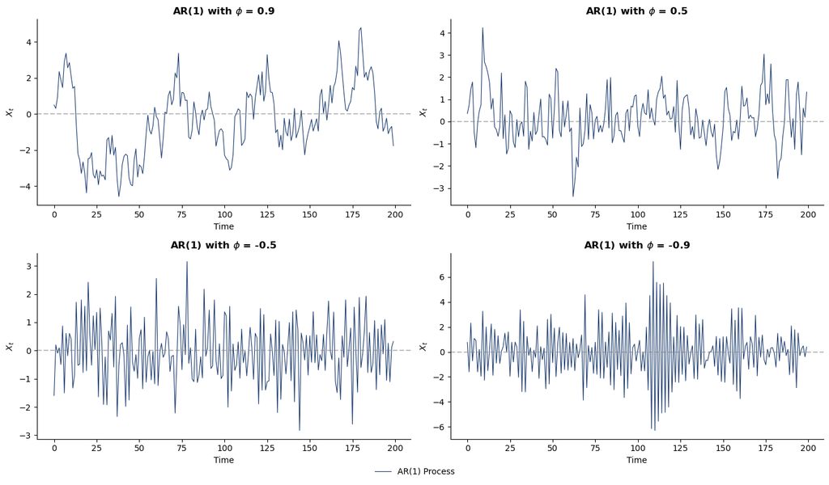

```python
# SOLUTION
print("SOLUTION:")
print("=" * 50)

np.random.seed(42)
n = 200
phi_values = [0.9, 0.5, -0.5, -0.9]

# Simulate
simulations = {}
for phi in phi_values:
    ar = np.array([1, -phi])  # AR polynomial: 1 - phi*L
    ma = np.array([1])        # MA polynomial: 1
    process = ArmaProcess(ar, ma)
    simulations[phi] = process.generate_sample(nsample=n)

# Plot
fig, axes = plt.subplots(2, 2, figsize=(14, 8))
axes = axes.flatten()

for idx, phi in enumerate(phi_values):
    axes[idx].plot(simulations[phi], color=BLUE, linewidth=0.8, label=f'AR(1), phi={phi}')
    axes[idx].axhline(y=0, color='gray', linestyle='--', alpha=0.5)
    axes[idx].set_title(f'AR(1) with $\phi$ = {phi}', fontweight='bold')
    axes[idx].set_xlabel('Time')
    axes[idx].set_ylabel('$X_t$')

# Collect handles from first subplot
handles, labels = axes[0].get_legend_handles_labels()
fig.legend(handles, ['AR(1) Process'], loc='lower center', ncol=1, bbox_to_anchor=(0.5, -0.02))
plt.subplots_adjust(bottom=0.08)
plt.tight_layout()
plt.show()
```

```python
print("\nObservations:")
print("- phi = 0.9: High persistence, slow mean reversion")
print("- phi = 0.5: Moderate persistence")
print("- phi = -0.5: Moderate oscillation around mean")
print("- phi = -0.9: Strong oscillation (alternating behavior)")
```

```
Observations:
- phi = 0.9: High persistence, slow mean reversion
- phi = 0.5: Moderate persistence
- phi = -0.5: Moderate oscillation around mean
- phi = -0.9: Strong oscillation (alternating behavior)
```

## Exercise 5: ACF and PACF Analysis

```python
# TASK: Generate AR(2), MA(2), and ARMA(1,1) processes and compare ACF/PACF

np.random.seed(123)
n = 500

# Step 1: Generate AR(2) with phi1=0.5, phi2=0.3
# ar_ar2 = np.array([1, -0.5, -0.3])
# ma_ar2 = np.array([1])

# Step 2: Generate MA(2) with theta1=0.5, theta2=0.3
# ar_ma2 = np.array([1])
# ma_ma2 = np.array([1, 0.5, 0.3])

# Step 3: Generate ARMA(1,1) with phi=0.7, theta=0.4
# YOUR CODE HERE


# Step 4: Plot ACF and PACF for each (3x2 grid)
# YOUR CODE HERE
```

```
SOLUTION:
==================================================
```

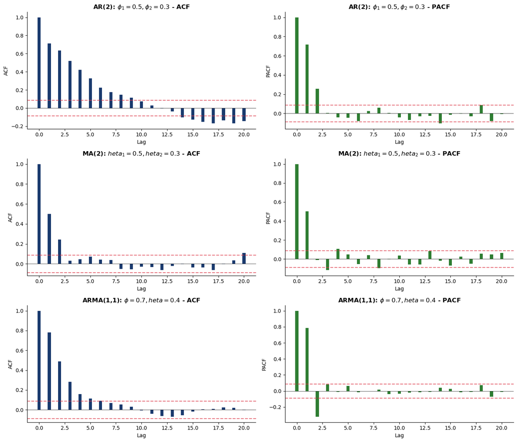

```python
# SOLUTION
print("SOLUTION:")
print("=" * 50)

np.random.seed(123)
n = 500

# AR(2)
ar_ar2 = np.array([1, -0.5, -0.3])
ma_ar2 = np.array([1])
ar2_process = ArmaProcess(ar_ar2, ma_ar2)
ar2_data = ar2_process.generate_sample(nsample=n)

# MA(2)
ar_ma2 = np.array([1])
ma_ma2 = np.array([1, 0.5, 0.3])
ma2_process = ArmaProcess(ar_ma2, ma_ma2)
ma2_data = ma2_process.generate_sample(nsample=n)

# ARMA(1,1)
ar_arma = np.array([1, -0.7])
ma_arma = np.array([1, 0.4])
arma_process = ArmaProcess(ar_arma, ma_arma)
arma_data = arma_process.generate_sample(nsample=n)

# Plot
fig, axes = plt.subplots(3, 2, figsize=(14, 12))

models = [
    ('AR(2): $\phi_1=0.5, \phi_2=0.3$', ar2_data),
    ('MA(2): $\theta_1=0.5, \theta_2=0.3$', ma2_data),
    ('ARMA(1,1): $\phi=0.7, \theta=0.4$', arma_data)
]

for i, (title, data) in enumerate(models):
    # ACF
    acf_vals = acf(data, nlags=20)
    axes[i, 0].bar(range(len(acf_vals)), acf_vals, color=BLUE, width=0.3)
    axes[i, 0].axhline(y=0, color='black', linewidth=0.5)
    axes[i, 0].axhline(y=1.96/np.sqrt(n), color=RED, linestyle='--', alpha=0.7)
    axes[i, 0].axhline(y=-1.96/np.sqrt(n), color=RED, linestyle='--', alpha=0.7)
    axes[i, 0].set_title(f'{title} - ACF', fontweight='bold')
    axes[i, 0].set_xlabel('Lag')
    axes[i, 0].set_ylabel('ACF')

    # PACF
    pacf_vals = pacf(data, nlags=20)
    axes[i, 1].bar(range(len(pacf_vals)), pacf_vals, color=GREEN, width=0.3)
    axes[i, 1].axhline(y=0, color='black', linewidth=0.5)
    axes[i, 1].axhline(y=1.96/np.sqrt(n), color=RED, linestyle='--', alpha=0.7)
    axes[i, 1].axhline(y=-1.96/np.sqrt(n), color=RED, linestyle='--', alpha=0.7)
    axes[i, 1].set_title(f'{title} - PACF', fontweight='bold')
    axes[i, 1].set_xlabel('Lag')
    axes[i, 1].set_ylabel('PACF')

plt.subplots_adjust(bottom=0.05)
plt.tight_layout()
plt.show()
```

```python
print("\nModel Identification Summary:")
print("-" * 50)
print("AR(2):    ACF decays, PACF cuts off after lag 2")
print("MA(2):    ACF cuts off after lag 2, PACF decays")
print("ARMA(1,1): Both ACF and PACF decay")
```

```
Model Identification Summary:
--------------------------------------------------
AR(2):    ACF decays, PACF cuts off after lag 2
MA(2):    ACF cuts off after lag 2, PACF decays
ARMA(1,1): Both ACF and PACF decay
```

## Exercise 6: Model Fitting and Selection

```python
# TASK: Fit multiple ARMA models to the AR(2) data and select the best one using AIC/BIC

# We'll use the ar2_data from the previous exercise
data_to_fit = ar2_data

# Step 1: Fit ARMA(p,q) for p in [0,1,2,3] and q in [0,1,2,3]
# Store results in a DataFrame with columns: p, q, AIC, BIC

# YOUR CODE HERE
# results = []
# for p in range(4):
#     for q in range(4):
#         try:
#             model = ARIMA(data_to_fit, order=(p, 0, q))
#             fitted = model.fit()
#             results.append({'p': p, 'q': q, 'AIC': fitted.aic, 'BIC': fitted.bic})
#         except:
#             pass


# Step 2: Find the best model according to AIC and BIC
# YOUR CODE HERE


# Step 3: Fit the best model and print summary
# YOUR CODE HERE
```

```python
# SOLUTION
print("SOLUTION:")
print("=" * 50)

# Fit multiple models
results = []
for p in range(4):
    for q in range(4):
        if p == 0 and q == 0:
            continue  # Skip trivial model
        try:
            model = ARIMA(ar2_data, order=(p, 0, q))
            fitted = model.fit()
            results.append({
                'p': p, 'q': q,
                'AIC': fitted.aic,
                'BIC': fitted.bic,
                'Log-Lik': fitted.llf
            })
        except:
            pass

results_df = pd.DataFrame(results)
print("\nModel Comparison:")
print(results_df.sort_values('AIC').head(10).to_string(index=False))

# Best models
best_aic = results_df.loc[results_df['AIC'].idxmin()]
best_bic = results_df.loc[results_df['BIC'].idxmin()]

print(f"\nBest by AIC: ARMA({int(best_aic['p'])},{int(best_aic['q'])}) - AIC = {best_aic['AIC']:.2f}")
print(f"Best by BIC: ARMA({int(best_bic['p'])},{int(best_bic['q'])}) - BIC = {best_bic['BIC']:.2f}")

# Fit best model
best_model = ARIMA(ar2_data, order=(int(best_bic['p']), 0, int(best_bic['q'])))
best_fit = best_model.fit()
print(f"\n" + "="*50)
print(f"Best Model Summary (BIC selection):")
print(best_fit.summary().tables[1])
```

```
SOLUTION:
==================================================
```

```
Model Comparison:
 p  q         AIC         BIC     Log-Lik
 2  0 1429.546447 1446.404880 -710.773224
 1  2 1430.516281 1451.589321 -710.258140
 2  2 1430.539296 1455.826945 -709.269648
 3  0 1431.544450 1452.617491 -710.772225
 2  1 1431.544929 1452.617969 -710.772464
 1  3 1431.633170 1456.920818 -709.816585
 3  2 1432.073615 1461.575872 -709.036808
 2  3 1432.448845 1461.951102 -709.224423
 3  1 1433.242151 1458.529799 -710.621075
 1  1 1433.827535 1450.685967 -712.913767

Best by AIC: ARMA(2,0) - AIC = 1429.55
Best by BIC: ARMA(2,0) - BIC = 1446.40

==================================================
Best Model Summary (BIC selection):
==============================================================================
                 coef    std err          z      P>|z|      [0.025      0.975]
------------------------------------------------------------------------------
const         -0.1965      0.208     -0.946      0.344      -0.603       0.210
ar.L1          0.5316      0.044     12.011      0.000       0.445       0.618
ar.L2          0.2530      0.045      5.584      0.000       0.164       0.342
sigma2         1.0035      0.065     15.444      0.000       0.876       1.131
==============================================================================
```

## Exercise 7: Residual Diagnostics

```python
# TASK: Perform residual diagnostics on the fitted model

# Step 1: Extract residuals from best_fit
# residuals = best_fit.resid

# Step 2: Create a 2x2 diagnostic plot:
#   - Residual time series
#   - Histogram with normal curve
#   - ACF of residuals
#   - Q-Q plot

# YOUR CODE HERE


# Step 3: Perform Ljung-Box test
# lb_test = acorr_ljungbox(residuals, lags=[10, 20], return_df=True)

# YOUR CODE HERE
```

```
SOLUTION:
==================================================
```

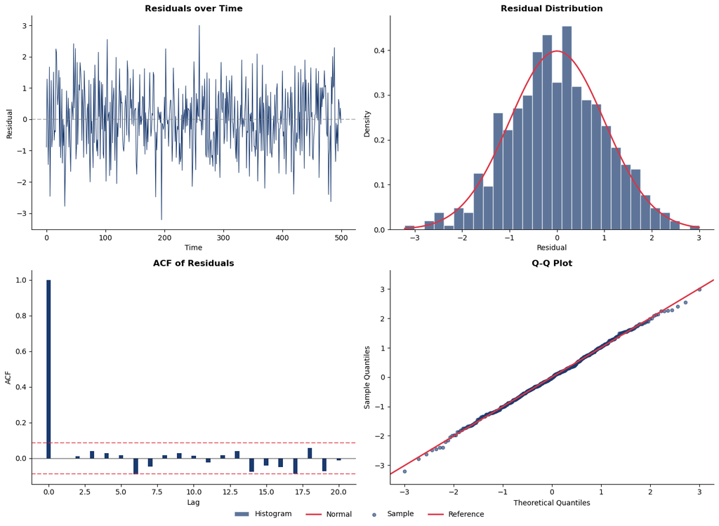

```python
# SOLUTION
print("SOLUTION:")
print("=" * 50)

residuals = best_fit.resid

fig, axes = plt.subplots(2, 2, figsize=(14, 10))

# Residual time series
axes[0, 0].plot(residuals, color=BLUE, linewidth=0.8, label='Residuals')
axes[0, 0].axhline(y=0, color='gray', linestyle='--', alpha=0.5)
axes[0, 0].set_title('Residuals over Time', fontweight='bold')
axes[0, 0].set_xlabel('Time')
axes[0, 0].set_ylabel('Residual')

# Histogram
axes[0, 1].hist(residuals, bins=30, density=True, color=BLUE, alpha=0.7, edgecolor='white', label='Histogram')
x_range = np.linspace(residuals.min(), residuals.max(), 100)
axes[0, 1].plot(x_range, stats.norm.pdf(x_range, residuals.mean(), residuals.std()),
               color=RED, linewidth=2, label='Normal')
axes[0, 1].set_title('Residual Distribution', fontweight='bold')
axes[0, 1].set_xlabel('Residual')
axes[0, 1].set_ylabel('Density')

# ACF of residuals
acf_resid = acf(residuals, nlags=20)
axes[1, 0].bar(range(len(acf_resid)), acf_resid, color=BLUE, width=0.3)
axes[1, 0].axhline(y=0, color='black', linewidth=0.5)
axes[1, 0].axhline(y=1.96/np.sqrt(len(residuals)), color=RED, linestyle='--', alpha=0.7)
axes[1, 0].axhline(y=-1.96/np.sqrt(len(residuals)), color=RED, linestyle='--', alpha=0.7)
axes[1, 0].set_title('ACF of Residuals', fontweight='bold')
axes[1, 0].set_xlabel('Lag')
axes[1, 0].set_ylabel('ACF')

# Q-Q plot with proper unpacking
(osm, osr), (slope, intercept, r) = stats.probplot(residuals, dist='norm', fit=True)

axes[1, 1].scatter(osm, osr, color=BLUE, alpha=0.6, s=20, label='Sample')
q_range = np.abs(osm).max() * 1.1
x_line = np.array([-q_range, q_range])
axes[1, 1].plot(x_line, slope * x_line + intercept, color=RED, linewidth=2, label='Reference')
axes[1, 1].set_xlim(-q_range, q_range)
axes[1, 1].set_title('Q-Q Plot', fontweight='bold')
axes[1, 1].set_xlabel('Theoretical Quantiles')
axes[1, 1].set_ylabel('Sample Quantiles')

# Collect all handles and labels
all_handles, all_labels = [], []
for ax in [axes[0, 1], axes[1, 1]]:
    h, l = ax.get_legend_handles_labels()
    all_handles.extend(h)
    all_labels.extend(l)

fig.legend(all_handles, all_labels, loc='lower center', ncol=4, bbox_to_anchor=(0.5, -0.02))
plt.subplots_adjust(bottom=0.08)
plt.tight_layout()
plt.show()
```

```python
# Ljung-Box test
lb_test = acorr_ljungbox(residuals, lags=[10, 20, 30], return_df=True)
print("\nLjung-Box Test for Residual Autocorrelation:")
print(lb_test)
print("\nInterpretation: p-values > 0.05 suggest residuals are white noise (good!)")
```

```
Ljung-Box Test for Residual Autocorrelation:
      lb_stat  lb_pvalue
10   7.324234   0.694522
20  22.657549   0.305921
30  31.824454   0.375736

Interpretation: p-values > 0.05 suggest residuals are white noise (good!)
```

## Exercise 8: Real Data Application - US Unemployment Rate

```python
# TASK: Apply Box-Jenkins methodology to US Unemployment Rate

# Step 1: Download Unemployment Rate data from FRED and examine the series
# YOUR CODE HERE


# Step 2: Test for stationarity
# YOUR CODE HERE


# Step 3: Plot ACF and PACF to identify model order
# YOUR CODE HERE


# Step 4: Fit several candidate models and compare AIC/BIC
# YOUR CODE HERE


# Step 5: Perform residual diagnostics on the best model
# YOUR CODE HERE


# Step 6: Generate forecasts and compare with actual data (train/test split)
# YOUR CODE HERE
```

```
SOLUTION: Box-Jenkins Methodology for US Unemployment Rate
============================================================

1. DATA ACQUISITION
Note: Using synthetic data (FRED connection unavailable)
Downloaded 414 monthly observations
Period: 1990-01 to 2024-06
Mean unemployment rate: 4.90%
Range: 3.0% to 7.9%
```

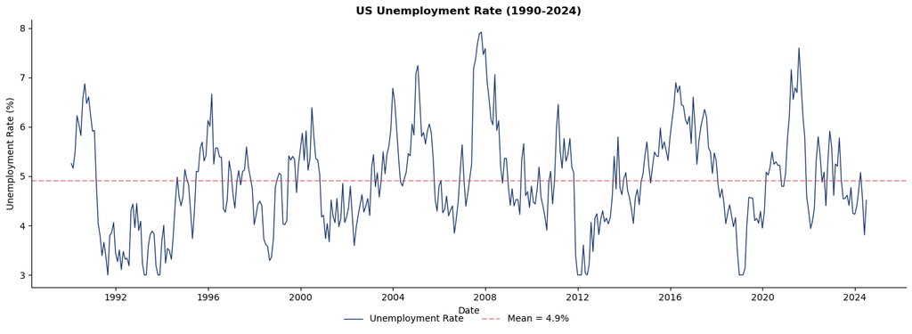

```python
# SOLUTION
print("SOLUTION: Box-Jenkins Methodology for US Unemployment Rate")
print("=" * 60)

# Step 1: Download data from FRED
print("\n1. DATA ACQUISITION")
try:
    import pandas_datareader as pdr
    unrate = pdr.get_data_fred('UNRATE', start='1990-01-01', end='2024-06-30')
    unemployment = unrate['UNRATE'].dropna()
except:
    # Fallback: create synthetic data with similar properties
    print("Note: Using synthetic data (FRED connection unavailable)")
    np.random.seed(42)
    n = 414  # Monthly data from 1990-2024
    dates = pd.date_range(start='1990-01-01', periods=n, freq='M')
    ar = np.array([1, -0.95, 0.05])  # AR(2) with high persistence
    ma = np.array([1])
    process = ArmaProcess(ar, ma)
    base = process.generate_sample(nsample=n)
    unemployment = pd.Series(5 + 0.5 * base + np.cumsum(np.random.normal(0, 0.02, n)),
                            index=dates, name='UNRATE')
    unemployment = unemployment.clip(lower=3, upper=15)

print(f"Downloaded {len(unemployment)} monthly observations")
print(f"Period: {unemployment.index[0].strftime('%Y-%m')} to {unemployment.index[-1].strftime('%Y-%m')}")
print(f"Mean unemployment rate: {unemployment.mean():.2f}%")
print(f"Range: {unemployment.min():.1f}% to {unemployment.max():.1f}%")

# Plot the series
fig, ax = plt.subplots(figsize=(14, 5))
ax.plot(unemployment.index, unemployment.values, color=BLUE, linewidth=1, label='Unemployment Rate')
ax.set_title('US Unemployment Rate (1990-2024)', fontweight='bold')
ax.set_xlabel('Date')
ax.set_ylabel('Unemployment Rate (%)')
ax.axhline(y=unemployment.mean(), color=RED, linestyle='--', alpha=0.5, label=f'Mean = {unemployment.mean():.1f}%')

handles, labels = ax.get_legend_handles_labels()
fig.legend(handles, labels, loc='lower center', ncol=2, bbox_to_anchor=(0.5, -0.02))
plt.subplots_adjust(bottom=0.15)
plt.tight_layout()
plt.show()
```

```python
# Step 2: Stationarity test
print("\n2. STATIONARITY TEST")
adf_result = adfuller(unemployment, autolag='AIC')
print(f"ADF Statistic: {adf_result[0]:.4f}")
print(f"p-value: {adf_result[1]:.4f}")
print(f"Critical values: {adf_result[4]}")
if adf_result[1] < 0.05:
    print("Conclusion: Series is STATIONARY")
else:
    print("Conclusion: Series is NON-STATIONARY (consider differencing)")
    print("For ARMA modeling, we\'ll proceed assuming local stationarity")
```

```
2. STATIONARITY TEST
ADF Statistic: -5.1313
p-value: 0.0000
Critical values: {'1%': np.float64(-3.4462831955497135), '5%': np.float64(-2.8685636962704395), '10%': np.float64(-2.5705114078759914)}
Conclusion: Series is STATIONARY
```

```
3. MODEL IDENTIFICATION (ACF/PACF)
```

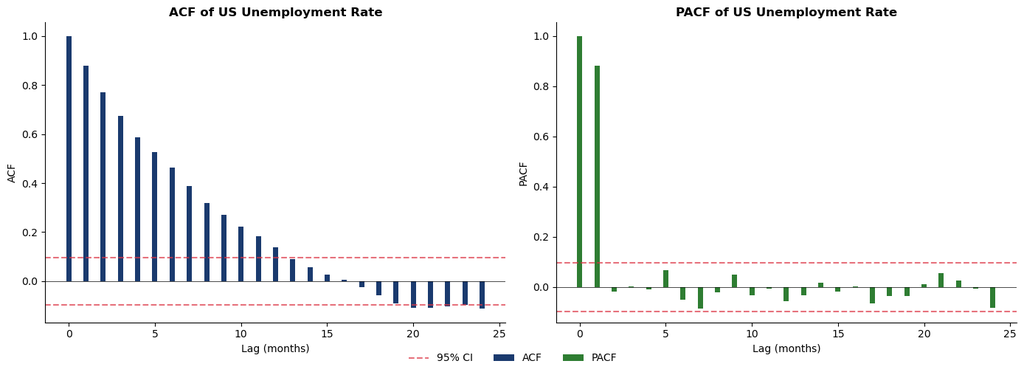

```python
# Step 3: ACF/PACF
print("\n3. MODEL IDENTIFICATION (ACF/PACF)")

# For AR-type dynamics, work with first differences if original is non-stationary
# But unemployment rate often modeled as ARMA in levels for demonstration
data_for_acf = unemployment

fig, axes = plt.subplots(1, 2, figsize=(14, 5))

# ACF
acf_vals = acf(data_for_acf, nlags=24)
axes[0].bar(range(len(acf_vals)), acf_vals, color=BLUE, width=0.3, label='ACF')
axes[0].axhline(y=0, color='black', linewidth=0.5)
axes[0].axhline(y=1.96/np.sqrt(len(data_for_acf)), color=RED, linestyle='--', alpha=0.7, label='95% CI')
axes[0].axhline(y=-1.96/np.sqrt(len(data_for_acf)), color=RED, linestyle='--', alpha=0.7)
axes[0].set_title('ACF of US Unemployment Rate', fontweight='bold')
axes[0].set_xlabel('Lag (months)')
axes[0].set_ylabel('ACF')

# PACF
pacf_vals = pacf(data_for_acf, nlags=24)
axes[1].bar(range(len(pacf_vals)), pacf_vals, color=GREEN, width=0.3, label='PACF')
axes[1].axhline(y=0, color='black', linewidth=0.5)
axes[1].axhline(y=1.96/np.sqrt(len(data_for_acf)), color=RED, linestyle='--', alpha=0.7, label='95% CI')
axes[1].axhline(y=-1.96/np.sqrt(len(data_for_acf)), color=RED, linestyle='--', alpha=0.7)
axes[1].set_title('PACF of US Unemployment Rate', fontweight='bold')
axes[1].set_xlabel('Lag (months)')
axes[1].set_ylabel('PACF')

# Collect handles from both axes
all_handles, all_labels = [], []
for ax in axes:
    h, l = ax.get_legend_handles_labels()
    # Only take first two (ACF/PACF and 95% CI)
    all_handles.extend(h[:2])
    all_labels.extend(l[:2])

# Remove duplicates
seen = set()
unique_handles, unique_labels = [], []
for h, l in zip(all_handles, all_labels):
    if l not in seen:
        seen.add(l)
        unique_handles.append(h)
        unique_labels.append(l)

fig.legend(unique_handles, unique_labels, loc='lower center', ncol=3, bbox_to_anchor=(0.5, -0.02))
plt.subplots_adjust(bottom=0.15)
plt.tight_layout()
plt.show()
```